# Lung tissue analysis

Alistair Bailey

18th January 2018

## Overview

This analysis is of data derived from a lung tissue sample from Southampton processed in Oxford using two mass spectrometers:

1. Thermo Lumos
2. Thermo Q-Exactive (aka QE).

The sample was prepared and analysed by Ben Nicholas, Annalisa Nicastri and Nicola Ternette during December 2017 and January 2018.

The tissue sample was split into four before immunoaffinity purification of the peptides, and then split again to run on the two spectrometers. Therefore we examine four replications of immunoaffinity purification on two spectrometers.

Analysis of the raw spectrometer files has been performed using Peaks 8.5. The search settings were:

- Default for the data refinement
- Precursor mass tolerance of 5ppm
- Fragment mass tolerance of 0.03 Da
- The database for searches was 20170518_SPhs.fasta
- Searches were filtered at 1% FDR using 80% ALC for the de novo identifications
- No modifications were set for the de novo and database searches
- The PTM module was run after the database search and concluded the Peaks analysis pipeline.
- Peaks analysis was performed for combined replicates and for individual replicates.

The tabs below show analysis of the peptides identified from the Peaks search pipeline. All analysis is performed in R.

### Processing of input files

The output from Peaks are .csv files containing 16 variable names. Here they are cleaned to remove white spaces and special characters:

```
##  [1] "peptide"             "x_10lgp"             "mass"
##  [4] "length"              "ppm"                 "m_z"
##  [7] "rt"                  "intensity_qesamplea" "fraction"
## [10] "scan"                "source_file"         "x_spec"
## [13] "x_spec_qesamplea"    "accession"           "ptm"
## [16] "ascore"
```

To these are added identifiers for the experimental replicate and the spectrometer used. Therefore there are eight experiments in total.

The strings associated with PTMs on the peptides are removed from the peptide sequences.

### Comparision of the peptide sequence motif

Using sequences identified across all replicates, the peptide motif for sequences of nine amino acids in length is shown below. Comparison is made between QE and Lumos spectrometer, and for the 9-mer sequences from both the QE and Lumos data, labelled ‘Consensus’.

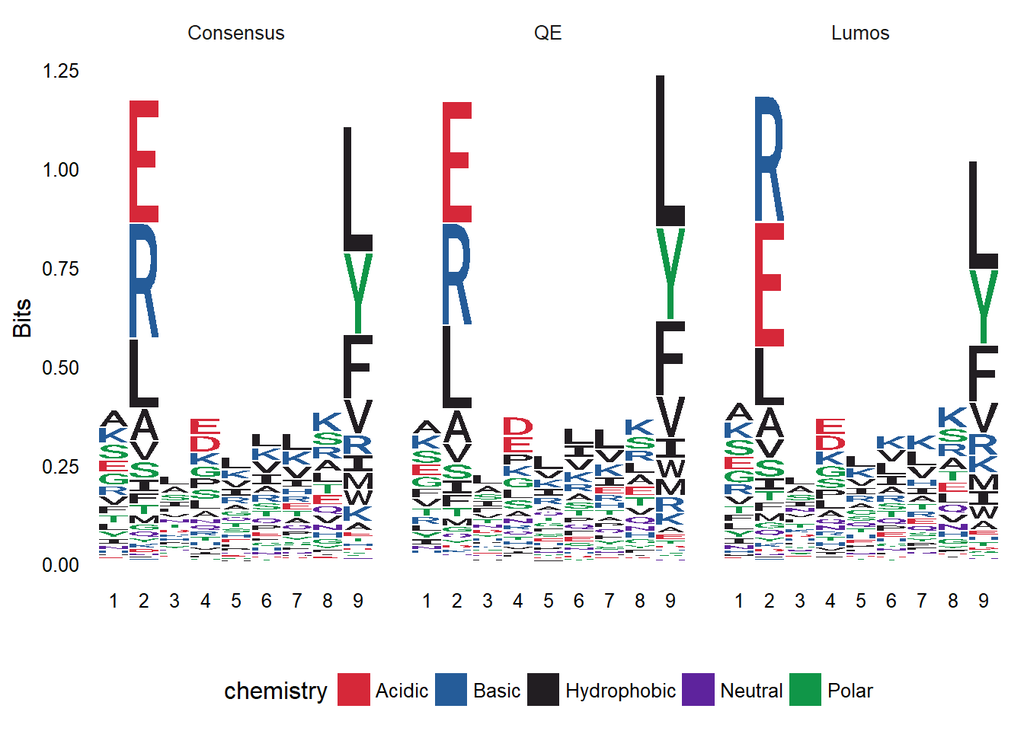

### Peptide length distributions

Peptide length distributions for combined replicates, comparing spectrometers for percentage of identifications between 8 and 15 amino acids in length.

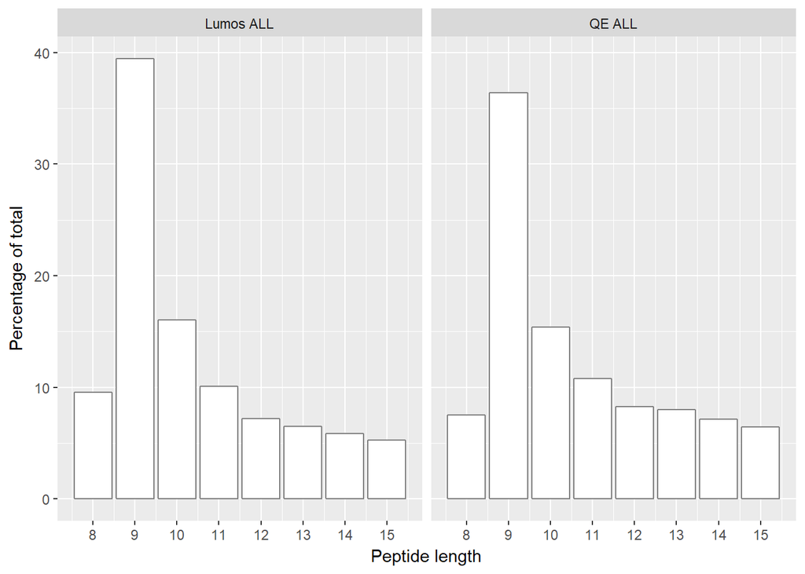

Peptide length distributions for each replicate and comparing spectrometers for percentage of identifications between 8 and 15 amino acids in length.

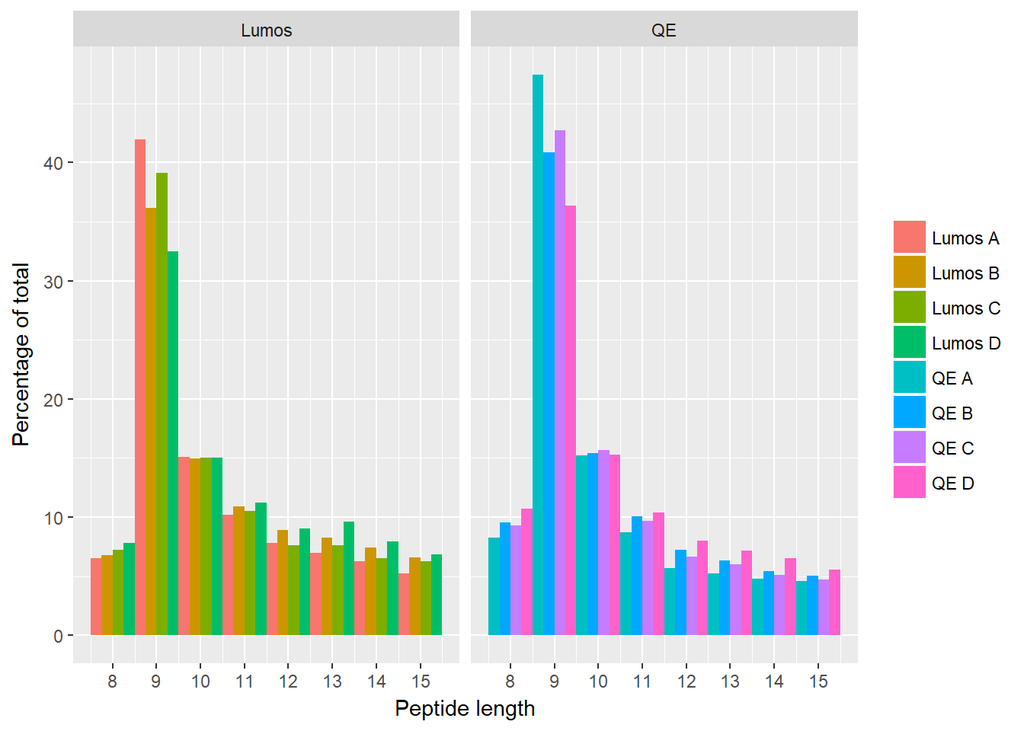

Comparison of number of peptide identifications per replicate and machine:

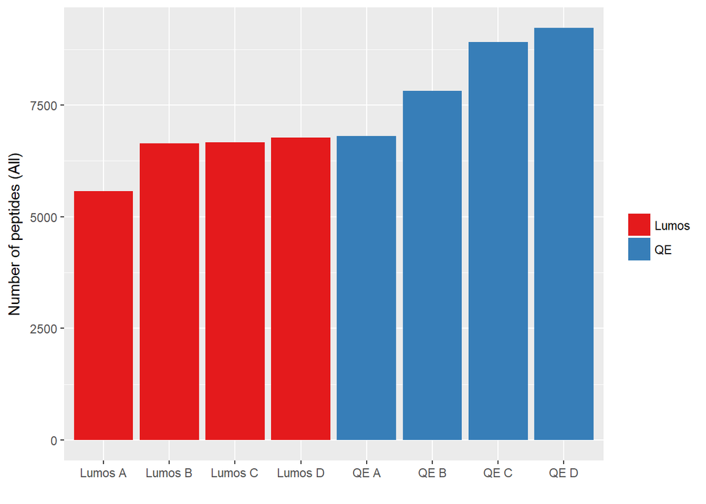

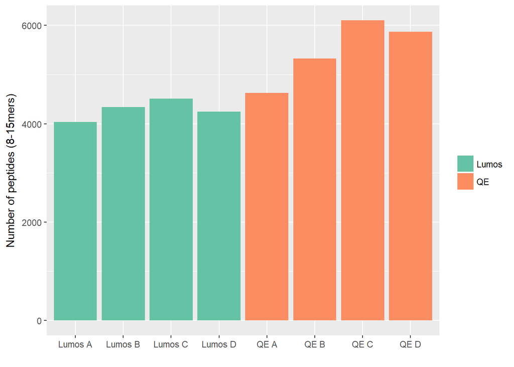

### Peptide summary tables

Summary of peptide lengths for identifications between 8 and 15 amino acids in length for combined replicates between spectrometers:

| exp_name | length | n_peps | percent |
| --- | --- | --- | --- |
| Lumos ALL | 8 | 865 | 9.56 |
| Lumos ALL | 9 | 3571 | 39.45 |
| Lumos ALL | 10 | 1452 | 16.04 |
| Lumos ALL | 11 | 915 | 10.11 |
| Lumos ALL | 12 | 653 | 7.21 |
| Lumos ALL | 13 | 588 | 6.5 |
| Lumos ALL | 14 | 531 | 5.87 |
| Lumos ALL | 15 | 477 | 5.27 |
| QE ALL | 8 | 547 | 7.51 |
| QE ALL | 9 | 2655 | 36.43 |

[output cut: 6 more lines]

Summary of peptide lengths for identifications between 8 and 15 amino acids in length for each replicate and between spectrometers:

| machine | exp_name | length | n_peps | percent |
| --- | --- | --- | --- | --- |
| Lumos | Lumos A | 8 | 262 | 6.5 |
| Lumos | Lumos A | 9 | 1691 | 41.94 |
| Lumos | Lumos A | 10 | 609 | 15.1 |
| Lumos | Lumos A | 11 | 410 | 10.17 |
| Lumos | Lumos A | 12 | 314 | 7.79 |
| Lumos | Lumos A | 13 | 282 | 6.99 |
| Lumos | Lumos A | 14 | 253 | 6.27 |
| Lumos | Lumos A | 15 | 211 | 5.23 |
| Lumos | Lumos B | 8 | 295 | 6.8 |
| Lumos | Lumos B | 9 | 1569 | 36.18 |

[output cut: 54 more lines]

### Venn diagrams of replicates

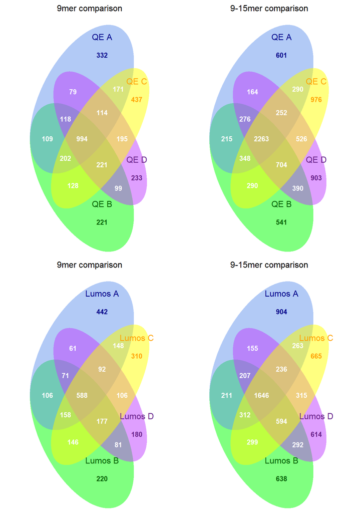

### MaxQuant & Peaks QE comparison

Plot distributions

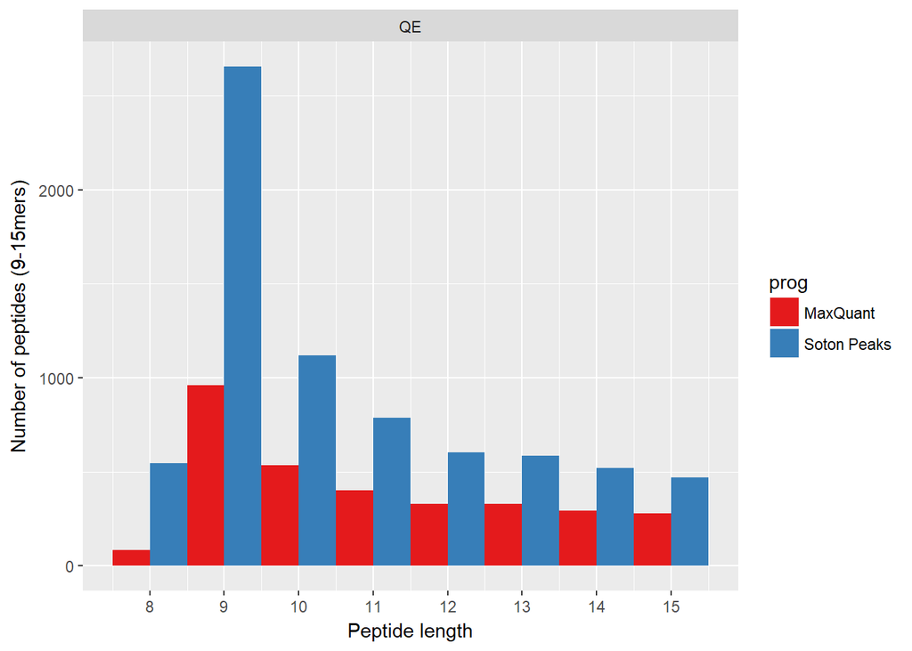

Venn diagram comparing Peaks and MaxQuant identifications.

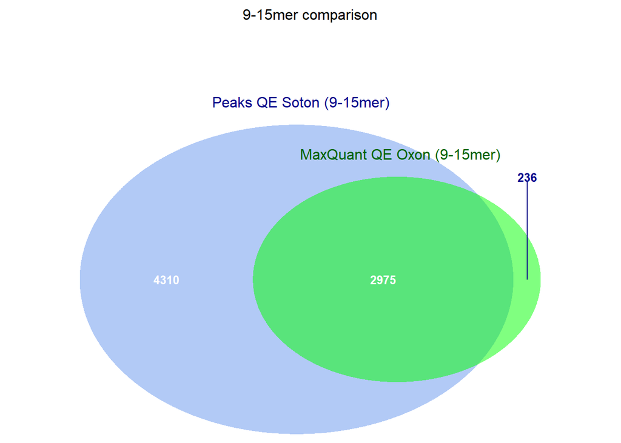

### MaxQuant QE Label Free analysis

Pairwise plot of QE samples label free quantification

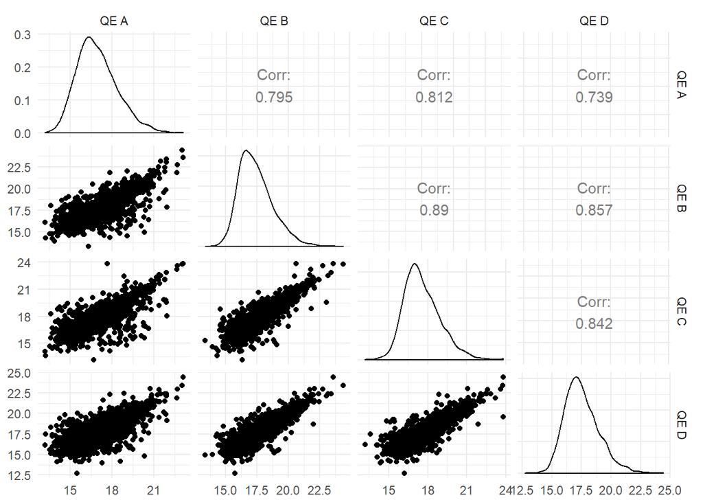